# Oyster Survey Effort Reallocation and Restratification

Robert Isdell

July 21, 2019

The following document summarizes our efforts-to-date to restratify and reallocate effort within the annual oyster survey. This work has relied heavily on the R package **BioSurvey2** written by the late Stephen Smith and distributed by SCeMFIS (http://www.scemfis.org/).

# Introduction

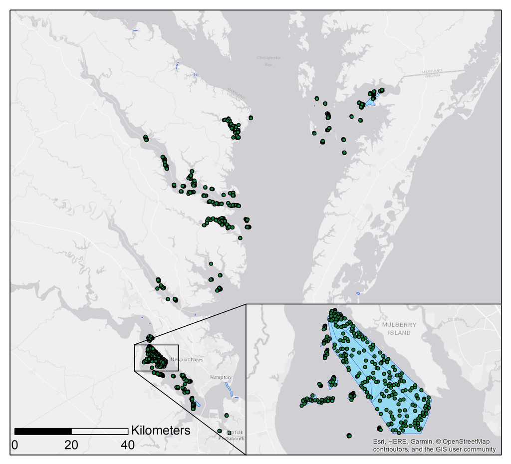

Since 1993:

- 199 Reefs
- 8 regions
- ~1,000 person hours year<sup>-1</sup>
- 1.2 million oysters measured

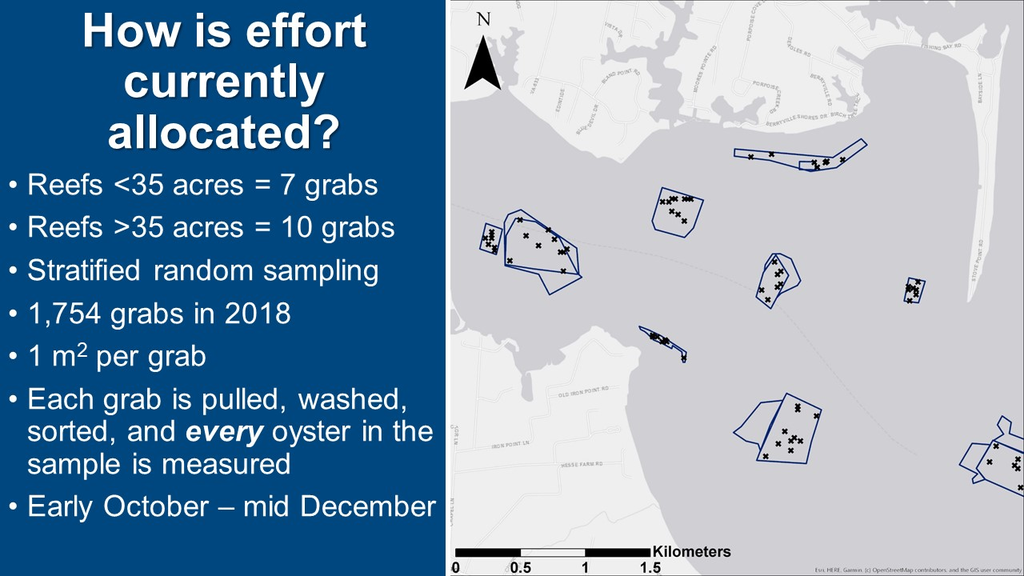

# James River

The James River did not have predefined management subgroups, and so was stratified using the k-means method.

## Set up strata and summarize

The following table provides the number of grabs from each reef from 2006-2018 (Observed) and the number of grabs over that same time frame, given the same total effort within the James, that would have best addressed total catch and the variability of the catch relative to the area of the reef.

| Strata | Observed | Optimal |
| --- | --- | --- |
| 40 | 199 | 223 |
| 123 | 429 | 418 |
| 131 | 311 | 8 |
| 174 | 390 | 553 |
| 193 | 130 | 25 |
| 198 | 218 | 70 |
| 226 | 131 | 130 |
| 326 | 520 | 765 |
| 327 | 111 | 40 |
| 328 | 91 | 22 |
| 329 | 127 | 151 |
| 330 | 130 | 88 |
| 331 | 88 | 11 |
| 332 | 213 | 152 |
| 335 | 91 | 4 |
| 336 | 91 | 10 |
| 338 | 286 | 300 |
| 339 | 389 | 617 |
| 340 | 390 | 1049 |
| 341 | 390 | 937 |
| 342 | 391 | 238 |
| 343 | 390 | 710 |
| 346 | 91 | 19 |
| 347 | 91 | 6 |
| 348 | 91 | 17 |
| 361 | 91 | 2 |
| 368 | 91 | 2 |
| 369 | 92 | 4 |
| 370 | 130 | 40 |
| 373 | 130 | 44 |
| 374 | 132 | 47 |
| 375 | 103 | 7 |
| 376 | 92 | 10 |
| 377 | 91 | 12 |
| Total | 6731 | 6731 |

## Clustering

One way to address the effort reallocation problem is to rexamine the current stratification, and see if we can reduce the number of strata while still getting accurate estimates of the mean and variation of the population within each strata. To do this, we can see if certain reefs cluster together based on similar features. I used the mean and variance of live oysters within each reef, and the acreage of each reef as factors for a K-means clustering analysis.

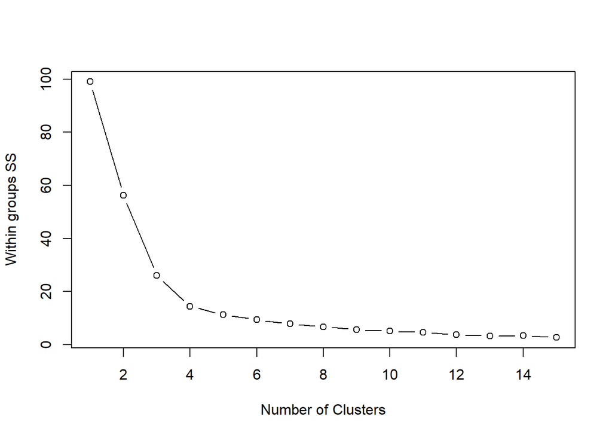

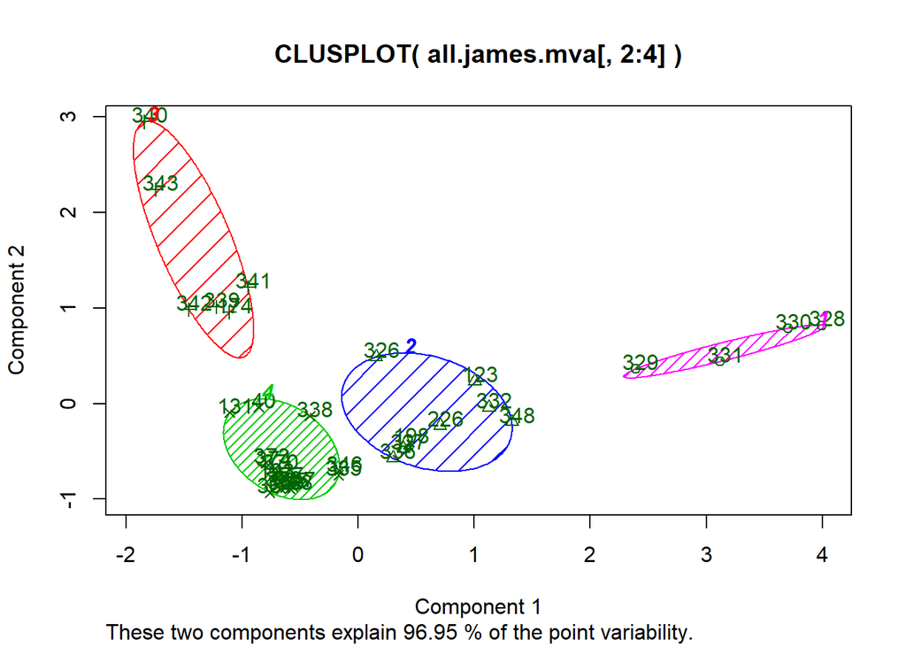

This plot shows how well those reefs cluster.

Suggested Strata

| Code | Cluster | Full_station_name |
| --- | --- | --- |
| 328 | 1 | UPPER HORSEHEAD |
| 329 | 1 | MIDDLE HORSEHEAD |
| 330 | 1 | LOWER HORSEHEAD |
| 331 | 1 | MOON ROCK |
| 123 | 2 | POINT OF SHOALS |
| 198 | 2 | LONG ROCK also Cross Rock |
| 226 | 2 | MULBERRY POINT |
| 326 | 2 | UPPER DEEP WATER SHOAL |
| 327 | 2 | LOWER DEEP WATER SHOAL |
| 332 | 2 | V-ROCK |
| 336 | 2 | DRY LUMPS |
| 348 | 2 | TRIANGLE ROCK |
| 174 | 3 | WRECK INSHORE |
| 339 | 3 | UPPER JAIL ISLAND |
| 340 | 3 | SWASH MUD SLOUGH |
| 341 | 3 | OFFSHORE SWASH |
| 342 | 3 | LOWER JAIL ISLAND |
| 343 | 3 | OFFSHORE JAIL ISLAND |
| 40 | 4 | DAYS POINT |
| 131 | 4 | NANSEMOND RIDGE |
| 193 | 4 | CRUISER’S SHOAL |
| 335 | 4 | SHANTY ROCK |
| 338 | 4 | SWASH |
| 346 | 4 | HOTEL ROCK |
| 347 | 4 | SNYDER’S ROCK |
| 361 | 4 | TANNER POINT |
| 368 | 4 | HULL CREEK |
| 369 | 4 | HOSPITAL POINT |
| 370 | 4 | BALLARD’S MARSH |
| 373 | 4 | THOMAS ROCK UPPER |
| 374 | 4 | THOMAS ROCK LOWER |
| 375 | 4 | DOG SHOAL UPPER |
| 376 | 4 | DOG SHOAL LOWER |
| 377 | 4 | HIGH SHOAL |

## Add new suggested groups and check allocation

How well is effort allocated based on current strata?

| Strata | Observed | Optimal | Perc.Increase.Var.opt | Compromise | Perc.Increase.Var.comp |
| --- | --- | --- | --- | --- | --- |
| 1 | 436 | 434 | 0.00014 | 434 | 0 |
| 2 | 1804 | 1266 | 2.38368 | 1266 | 0 |
| 3 | 2340 | 4643 | 33.67382 | 4643 | 0 |
| 4 | 2151 | 388 | 21.46766 | 388 | 0 |
| Total | 6731 | 6731 | 57.52530 | 6731 | 0 |

Overall, effort allocation is inefficient within the new strata.

## Estimate the population mean and variance given the new strata and allocation

### Simulate the data

We can resample the data at the proportions suggested by BIOSurvey2, sequentially reduce the effort by 10% across all strata, and then plot the results. We are effectively creating 100 datasets per proportional effort reduction for a total of 1000 datasets. Each one is the result of resampling (with replacement). Then, we can plot the mean of each strata within the datasets for each proportional effort reduction, and get a sense of what the spread in the data would look like. By plotting the 95% CI of the data, a wedge forms as the estimates become less accurate with increasing proportional reduction. Identifying the point where our overall interpretation of the data remains more-or-less the same while maximixing effort reduction should provide support for how much we could reduce effort within a given waterbody.

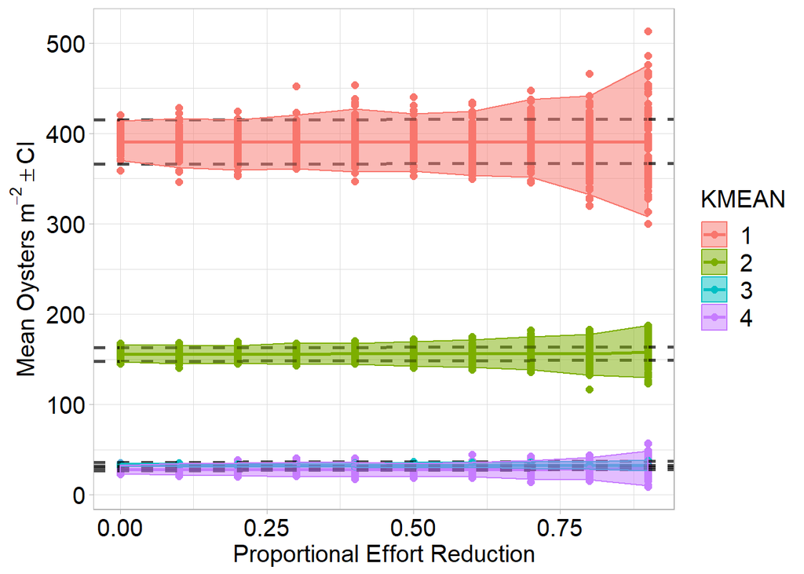

In this plot, you can see that the mean and CI remain relatively constant through a 40% reduction in effort.

Population Stats based on all data

| kmeans | pMEAN | pSD | pVAR | nOBS | lower.ci.mean | upper.ci.mean |
| --- | --- | --- | --- | --- | --- | --- |
| 1 | 390.312 | 260.300 | 67756.1 | 436 | 365.811 | 414.813 |
| 2 | 156.186 | 166.160 | 27609.3 | 1804 | 148.513 | 163.858 |
| 3 | 33.009 | 64.568 | 4169.0 | 2340 | 30.391 | 35.626 |
| 4 | 27.964 | 55.701 | 3102.6 | 2151 | 25.609 | 30.319 |

Mean of the means

| ER | KMEAN | m.MEAN | sd.MEAN | lower.ci.mean | upper.ci.mean |
| --- | --- | --- | --- | --- | --- |
| 0.0 | 1 | 391.909 | 10.88642 | 370.308 | 413.510 |
| 0.1 | 1 | 389.551 | 13.62404 | 362.518 | 416.584 |
| 0.2 | 1 | 387.516 | 14.04354 | 359.650 | 415.381 |
| 0.3 | 1 | 390.809 | 15.07134 | 360.905 | 420.714 |
| 0.4 | 1 | 392.228 | 17.55773 | 357.390 | 427.067 |
| 0.5 | 1 | 390.046 | 16.12259 | 358.055 | 422.036 |
| 0.6 | 1 | 389.130 | 17.81645 | 353.779 | 424.482 |
| 0.7 | 1 | 394.535 | 21.69859 | 351.480 | 437.589 |
| 0.8 | 1 | 387.022 | 27.46420 | 332.527 | 441.517 |
| 0.9 | 1 | 391.489 | 42.23509 | 307.685 | 475.293 |
| 0.0 | 2 | 156.148 | 4.66903 | 146.884 | 165.412 |
| 0.1 | 2 | 155.272 | 5.12229 | 145.108 | 165.436 |
| 0.2 | 2 | 155.426 | 4.91232 | 145.679 | 165.173 |
| 0.3 | 2 | 156.235 | 6.01369 | 144.303 | 168.168 |
| 0.4 | 2 | 155.991 | 5.94314 | 144.199 | 167.784 |
| 0.5 | 2 | 156.165 | 6.80324 | 142.666 | 169.664 |
| 0.6 | 2 | 156.388 | 7.55271 | 141.401 | 171.374 |
| 0.7 | 2 | 156.847 | 9.23054 | 138.532 | 175.163 |
| 0.8 | 2 | 154.918 | 11.38123 | 132.335 | 177.501 |
| 0.9 | 2 | 158.780 | 14.62605 | 129.758 | 187.801 |
| 0.0 | 3 | 32.864 | 0.93217 | 31.014 | 34.714 |
| 0.1 | 3 | 32.960 | 0.95748 | 31.060 | 34.860 |
| 0.2 | 3 | 32.739 | 1.03979 | 30.676 | 34.802 |
| 0.3 | 3 | 33.013 | 1.04213 | 30.945 | 35.080 |
| 0.4 | 3 | 32.871 | 1.15333 | 30.582 | 35.159 |
| 0.5 | 3 | 32.894 | 1.40023 | 30.115 | 35.672 |
| 0.6 | 3 | 33.054 | 1.32499 | 30.425 | 35.683 |
| 0.7 | 3 | 33.087 | 1.74518 | 29.624 | 36.550 |
| 0.8 | 3 | 32.606 | 2.00364 | 28.630 | 36.581 |
| 0.9 | 3 | 32.706 | 3.07741 | 26.600 | 38.812 |
| 0.0 | 4 | 28.011 | 2.49386 | 23.063 | 32.960 |
| 0.1 | 4 | 28.119 | 3.12375 | 21.920 | 34.317 |
| 0.2 | 4 | 28.440 | 3.45707 | 21.580 | 35.299 |
| 0.3 | 4 | 27.977 | 3.96680 | 20.106 | 35.848 |
| 0.4 | 4 | 28.039 | 4.03156 | 20.040 | 36.039 |
| 0.5 | 4 | 27.464 | 3.67936 | 20.164 | 34.765 |
| 0.6 | 4 | 27.958 | 4.06584 | 19.890 | 36.025 |
| 0.7 | 4 | 27.458 | 5.12768 | 17.283 | 37.632 |
| 0.8 | 4 | 28.981 | 6.15577 | 16.767 | 41.195 |
| 0.9 | 4 | 29.547 | 9.68974 | 10.320 | 48.773 |

| Cluster | Future Effort | Current Effort |
| --- | --- | --- |
| 1 | 20 | 34 |
| 2 | 58 | 139 |
| 3 | 214 | 180 |
| 4 | 18 | 165 |

This would mean a total of 310 grabs in the James Bay compared to 518 in previous years.

# Lynnhaven River

Lynnhaven remains unchanged from the previous iteration. If you all decide to continue, then there’s no need to restratify given how few reefs are down there and that it’s a full day either way. However, if you do continue sampling, BIOSurvey2 does recommend reallocating effort.

## Set up strata and summarize

| Strata | Observed | Optimal |
| --- | --- | --- |
| 1501 | 70 | 9 |
| 1502 | 70 | 1 |
| 1503 | 77 | 3 |
| 1504 | 77 | 3 |
| 1506 | 77 | 212 |
| 1507 | 80 | 166 |
| 1508 | 84 | 108 |
| 1509 | 84 | 25 |
| 1510 | 84 | 279 |
| 1511 | 76 | 76 |
| 1512 | 77 | 43 |
| 1513 | 77 | 8 |
| Total | 933 | 933 |

Each year, total effort (i.e., number of grabs) in each reef would be as follows:

| Strata | Annual Effort |
| --- | --- |
| 1501 | 1 |
| 1502 | 1 |
| 1503 | 1 |
| 1504 | 1 |
| 1506 | 17 |
| 1507 | 13 |
| 1508 | 9 |
| 1509 | 2 |
| 1510 | 22 |
| 1511 | 6 |
| 1512 | 4 |
| 1513 | 1 |

This would be a total of 78 grabs per year in the Lynnhaven.

# Rappahannock River

The Rappahannock has predefined management subgroups, thereby making any cluster analyses unneccesary. The results shown here demonstrate how the effort should be allocated among management subgroups.

## Set up strata and summarize

Rappahannock Reef and Management Subgroup

| Station_ID | Site | Management Subgroups |
| --- | --- | --- |
| 1001 | #1 Spike B Offshore | RRH1 |
| 1002 | #2 Spike A | RRH1 |
| 1003 | #3 Spike | RRH1 |
| 1004 | #4 Lower Edge East | RRH1 |
| 1005 | #5 Lower Edge Middle | RRH1 |
| 1006 | #6 Lower Edge West | RRH1 |
| 1007 | #7 Broad Creek | RRH1 |
| 1026 | #26 Mosquito Island | RRH1 |
| 1029 | #27-1 Butler’s Hole East | RRH1 |
| 1053 | #27-2 Butler’s Hole West | RRH1 |
| 1008 | #8 Sturgeon Bar East | RRH2 |
| 1009 | #9 Sturgeon Bar West | RRH2 |
| 1010 | #10 North End | RRH2 |
| 1011 | #11 Parrot Rock East | RRH3 |
| 1018 | #18 Drumming Ground Offshore | RRH4 |
| 1030 | #18.1 Drumming Ground Off Add | RRH4 |
| 1019 | #19 Drumming Ground Inshore | RRH4 |
| 1020 | #20 Corrotoman C-1 | RRH4 |
| 1021 | #21 Corrotoman C-2 | RRH4 |
| 1022 | #22 Corrotoman C-3 | RRH4 |
| 1023 | #23 Middle Ground | RRH4 |
| 1024 | #24 Ferry Rock | RRH4 |
| 1013 | #13 Temple Bay 1 | RRH5 |
| 1014 | #14 Temple Bay 2 | RRH5 |
| 1015 | #15 Temple Bay 3 | RRH5 |
| 1016 | #16 Temple Bay 4 | RRH5 |
| 1017 | #17 Temple Bay 5 | RRH5 |
| 1031 | #29 Whiting Creek | RRH6 |
| 1034 | #32 Hog House Inshore | RRH6 |
| 1035 | #33 Hog House Offshore | RRH6 |
| 1036 | #34 Little Wicks A | RRH7 |
| 1037 | #35 Little Wicks B | RRH7 |
| 1039 | #36.2 Big Wicks B | RRH7 |
| 1040 | #36.3 Big Wicks C | RRH7 |
| 1044 | #37 Stove Point | RRH7 |
| 1045 | #38 Smokey Point | RRH7 |
| 1047 | #39.2 Waterview B | RRH7 |
| 1048 | #39.3 Waterview C | RRH7 |
| 1028 | #28 Broad Creek Inshore | RRS1 |
| 1061 | #47 Broad Creek Sanctuary | RRS1 |
| 1064 | #50 Butler’s Hole Sanctuary | RRS1 |
| 1059 | #45 Upper Sturgeon Sanctuary | RRS2 |
| 1060 | #46 Lower Sturgeon Sanctuary | RRS2 |
| 1065 | #51 Mill Creek Sanctuary | RRS2 |
| 1066 | Bush Park | RRS2 |
| 1012 | #12 Parrot Rock West | RRS3 |
| 1025 | #25 Larson’s Bay | RRS3 |
| 1058 | #44 Parrots Rock Sanctuary | RRS3 |
| 1062 | #48 Upper Larson’s Sanctuary | RRS3 |
| 1063 | #49 Lower Larson’s Sanctuary | RRS3 |
| 1054 | #40 Drumming Ground Sanctuary | RRS4 |
| 1055 | #41 Drumming Ground Sanctuary | RRS4 |
| 1056 | #42 Corrotoman Sanctuary | RRS4 |
| 1057 | #43 Temple Bay Sanctuary | RRS5 |
| 1032 | #30 Whitehouse East | RRS6 |
| 1033 | #31 Whitehouse West | RRS6 |

Observed vs. Optimal Effort

| Strata | Observed | Optimal |
| --- | --- | --- |
| RRH1 | 911 | 1092 |
| RRH2 | 274 | 296 |
| RRH3 | 91 | 121 |
| RRH4 | 818 | 1115 |
| RRH5 | 463 | 314 |
| RRH6 | 273 | 190 |
| RRH7 | 729 | 706 |
| RRS1 | 259 | 411 |
| RRS2 | 281 | 150 |
| RRS3 | 435 | 245 |
| RRS4 | 260 | 157 |
| RRS5 | 86 | 55 |
| RRS6 | 182 | 212 |
| Total | 5062 | 5064 |

## Estimate the population mean and variance given the new strata and allocation

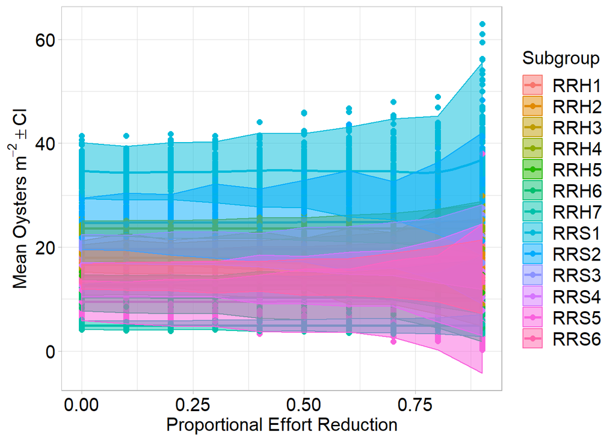

The current subgroups are *very* messy in terms of overlapping population estimates. However, it does still appear that a 40% reduction is possible in the Rappahannock.

Population Stats based on all data

| Subgroup | pMEAN | pSD | pVAR | nOBS | lower.ci.mean | upper.ci.mean |
| --- | --- | --- | --- | --- | --- | --- |
| RRH1 | 17.9473 | 24.976 | 623.78 | 911 | 16.3233 | 19.5713 |
| RRH2 | 18.0328 | 22.869 | 523.01 | 274 | 15.3130 | 20.7527 |
| RRH3 | 16.9121 | 24.865 | 618.26 | 91 | 11.7345 | 22.0897 |
| RRH4 | 23.5575 | 25.563 | 653.47 | 818 | 21.8031 | 25.3118 |
| RRH5 | 12.7430 | 15.568 | 242.38 | 463 | 11.3212 | 14.1648 |
| RRH6 | 10.3187 | 19.452 | 378.39 | 273 | 8.0009 | 12.6364 |
| RRH7 | 4.9108 | 10.345 | 107.03 | 729 | 4.1586 | 5.6631 |
| RRS1 | 34.6409 | 53.182 | 2828.34 | 259 | 28.1337 | 41.1482 |
| RRS2 | 24.8221 | 33.268 | 1106.75 | 281 | 20.9155 | 28.7286 |
| RRS3 | 19.6184 | 22.038 | 485.65 | 435 | 17.5417 | 21.6951 |
| RRS4 | 13.7346 | 20.231 | 409.30 | 260 | 11.2640 | 16.2052 |
| RRS5 | 9.4651 | 15.310 | 234.39 | 86 | 6.1832 | 12.7470 |
| RRS6 | 14.2857 | 17.572 | 308.76 | 182 | 11.7158 | 16.8556 |

Each year, total effort (i.e., number of grabs) in each cluster would be as follows:

| Subgroup | Future Effort | Current Effort |
| --- | --- | --- |
| RRH1 | 50 | 70 |
| RRH2 | 14 | 21 |
| RRH3 | 6 | 7 |
| RRH4 | 51 | 63 |
| RRH5 | 14 | 36 |
| RRH6 | 9 | 21 |
| RRH7 | 33 | 56 |
| RRS1 | 19 | 20 |
| RRS2 | 7 | 22 |
| RRS3 | 11 | 33 |
| RRS4 | 7 | 20 |
| RRS5 | 3 | 7 |
| RRS6 | 10 | 14 |

# Piankatank River

The Piankatank also lacked management subgroups, so clusters were identified.

## Set up strata and summarize

Observed vs. Optimal Effort

| Strata | Observed | Optimal |
| --- | --- | --- |
| 8 | 130 | 190 |
| 20 | 113 | 212 |
| 24 | 130 | 380 |
| 50 | 91 | 31 |
| 65 | 58 | 41 |
| 77 | 57 | 24 |
| 110 | 130 | 287 |
| 140 | 91 | 51 |
| 150 | 56 | 6 |
| 305 | 91 | 91 |
| 321 | 91 | 10 |
| 365 | 91 | 7 |
| 391 | 57 | 19 |
| 392 | 56 | 2 |
| 393 | 56 | 2 |
| 394 | 56 | 1 |
| Total | 1354 | 1354 |

## Clustering

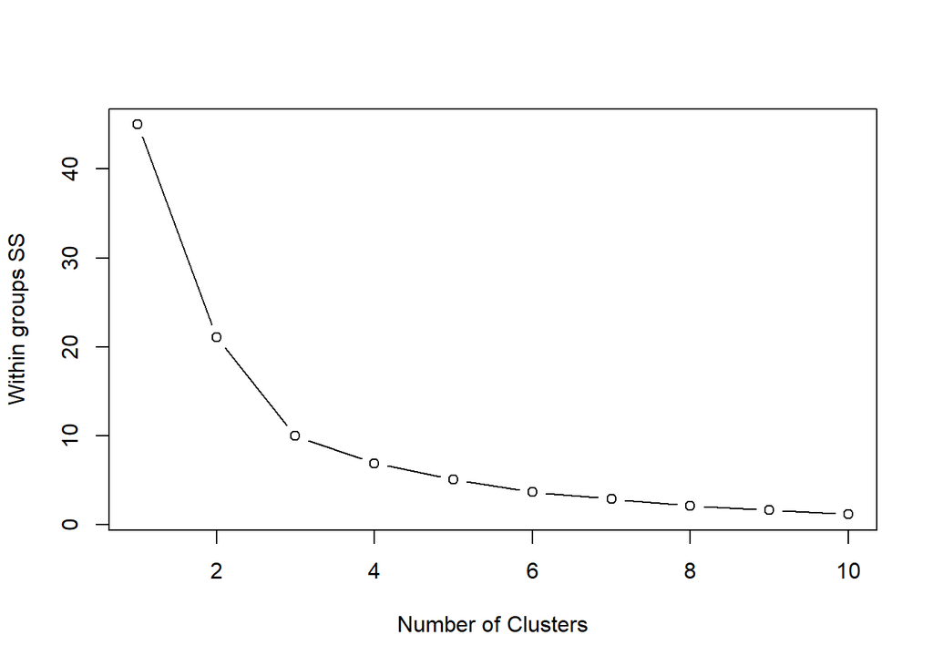

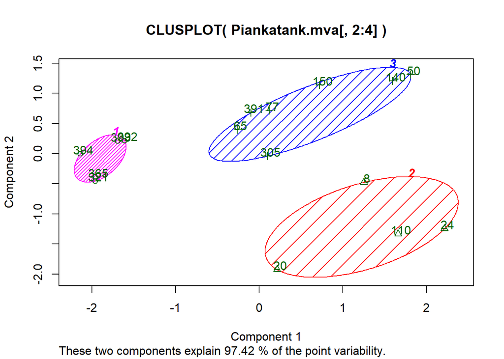

This plot shows how well those reefs cluster.

Suggested Strata

| Code | Cluster | Full_station_name |
| --- | --- | --- |
| 321 | 1 | BURTON POINT B also BURTON POINT 2 |
| 365 | 1 | PALACE BAR B also PALACE BAR 2 |
| 392 | 1 | SHIPLEYS EDGE |
| 393 | 1 | THOMPSONS |
| 394 | 1 | DOCS VIEW |
| 8 | 2 | BLAND POINT |
| 20 | 2 | BURTON POINT also BURTON POINT 1 |
| 24 | 2 | CAPE TUNE |
| 110 | 2 | PALACE BAR also PALACE BAR 1 |
| 50 | 3 | GINNEY POINT |
| 65 | 3 | HILLS BAY |
| 77 | 3 | ISLAND BAR |
| 140 | 3 | STOVE POINT |
| 150 | 3 | THREE BRANCHES |
| 305 | 3 | HERON ROCK |
| 391 | 3 | COBBS CREEK |

## Testing Stratification

How well is effort allocated based on current strata?

| Strata | Observed | Optimal |
| --- | --- | --- |
| 1 | 350 | 34 |
| 2 | 503 | 1151 |
| 3 | 501 | 169 |
| Total | 1354 | 1354 |

## Estimate the population mean and variance given the new strata and allocation

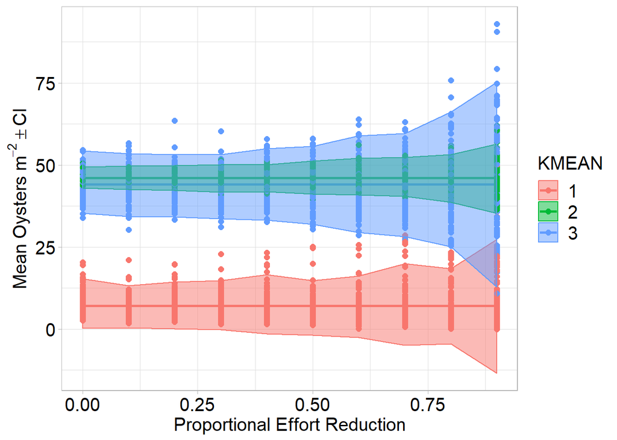

Population Stats based on all data

| kmeans | pMEAN | pSD | pVAR | nOBS | lower.ci.mean | upper.ci.mean |
| --- | --- | --- | --- | --- | --- | --- |
| 1 | 7.2286 | 18.49 | 341.89 | 350 | 5.2847 | 9.1724 |
| 2 | 46.1849 | 55.44 | 3073.62 | 503 | 41.3283 | 51.0415 |
| 3 | 44.2914 | 59.56 | 3547.40 | 501 | 39.0634 | 49.5194 |

Based on the information above, it appears that the total effort in the Piankatank could be reduced by 40% and still obtain similar population parameters. Each year, total effort (i.e., number of grabs) in each cluster would be as follows:

| Cluster | Future Effort | Current Effort |
| --- | --- | --- |
| 1 | 5 | 27 |
| 2 | 53 | 39 |
| 3 | 8 | 39 |

This would mean a total of 66 grabs in the Piankatank compared to 105 in previous years.

# York River

## Set up strata and summarize

York Reef and Management Subgroup

| Station_ID | Site | Management Subgroups |
| --- | --- | --- |
| 109 | Page’s Rock | MBYR1 |
| 1 | Aberdeen Rock | MBYR1 |
| 389 | Timberneck | MBYR2 |
| 210 | Pultz Bar | MBYR3 |
| 372 | Tow Stake West (25-1) | MBYR3 |
| 371 | Tow Stake East (25-2) | MBYR3 |
| 17 | Brown’s Bay 2 | MBYRNA |
| 387 | Indian Field | MBYRS |
| 388 | Cheatam P.G. 1 | MBYRS |

Observed vs. Optimal Effort

| Strata | Observed | Optimal |
| --- | --- | --- |
| MBYR1 | 401 | 628 |
| MBYR2 | 201 | 203 |
| MBYR3 | 275 | 123 |
| MBYRNA | 46 | 100 |
| MBYRS | 139 | 8 |
| Total | 1062 | 1062 |

## Estimate the population mean and variance given the new strata and allocation

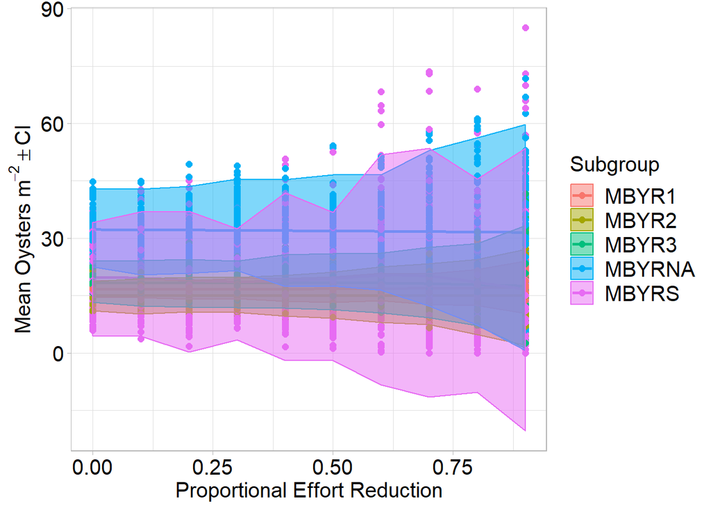

Population Stats based on all data

| Subgroup | pMEAN | pSD | pVAR | nOBS | lower.ci.mean | upper.ci.mean |
| --- | --- | --- | --- | --- | --- | --- |
| MBYR1 | 16.748 | 28.329 | 802.55 | 401 | 13.967 | 19.529 |
| MBYR2 | 15.075 | 31.180 | 972.18 | 201 | 10.738 | 19.411 |
| MBYR3 | 18.400 | 29.571 | 874.44 | 275 | 14.890 | 21.910 |
| MBYRNA | 32.652 | 54.834 | 3006.81 | 46 | 16.378 | 48.926 |
| MBYRS | 18.770 | 21.861 | 477.89 | 139 | 15.104 | 22.436 |

| Subgroup | Future Effort | Current Effort |
| --- | --- | --- |
| MBYR1 | 39 | 31 |
| MBYR2 | 12 | 15 |
| MBYR3 | 8 | 21 |
| MBYRNA | 6 | 4 |
| MBYRS | 7 | 11 |

This would mean a total of 72 grabs in the York compared to 82 in previous years.

# Great Wicomico River

The Great Wicomico also has both management subgroups as well as unassigned reefs. Unlike the York, however, there are several reefs that are unassigned, and so a cluster analysis was run on the unassigned, and then the new groups were added to the management subgroups.

## Set up strata and summarize

| Strata | Observed | Optimal |
| --- | --- | --- |
| 187 | 91 | 65 |
| 407 | 85 | 54 |
| 409 | 91 | 91 |
| 1301 | 91 | 103 |
| 1303 | 94 | 48 |
| 1304 | 94 | 41 |
| 1308 | 92 | 125 |
| 1309 | 94 | 167 |
| 1310 | 95 | 66 |
| 1311 | 91 | 264 |
| 1312 | 93 | 5 |
| 1313 | 90 | 112 |
| 1315 | 94 | 20 |
| 1316 | 91 | 125 |
| Total | 1286 | 1286 |

## Clustering

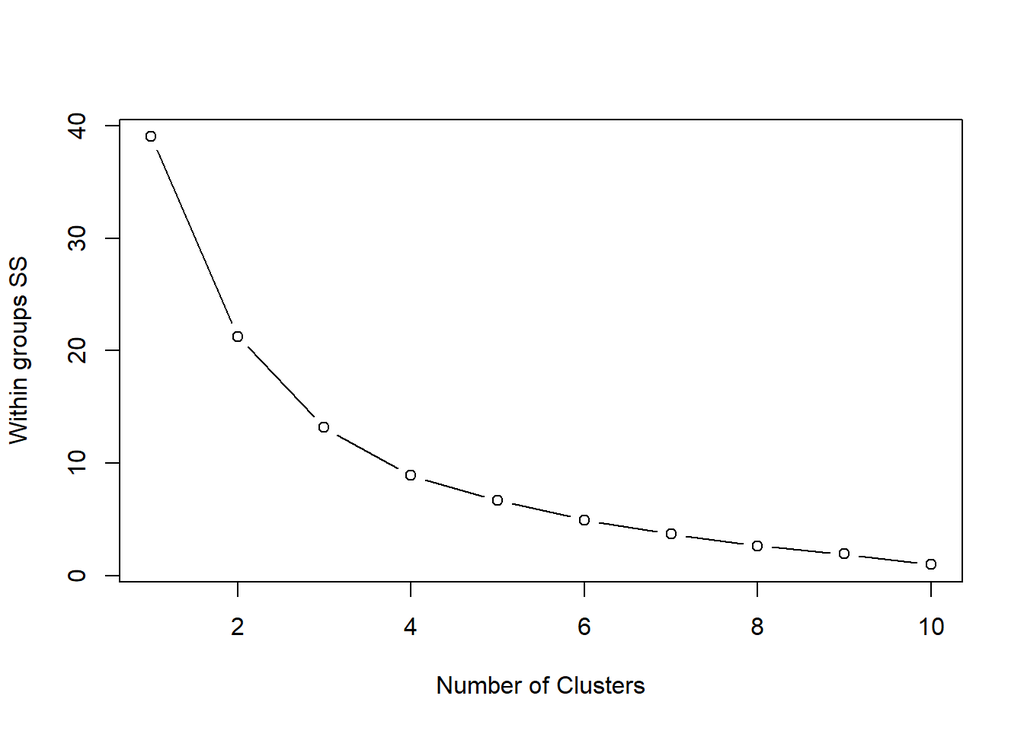

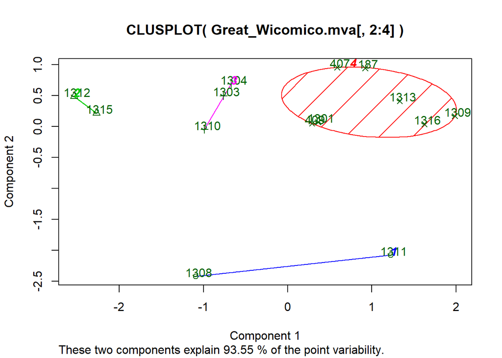

This plot shows how well those reefs cluster.

Suggested Strata

| Code | Cluster | Full_station_name |
| --- | --- | --- |
| 1308 | 1 | VMRC 8/GW Corps 9 |
| 1311 | 1 | VMRC 11/GW Corps 14,15 & 16 |
| 1312 | 2 | VMRC 12/GW Corps 17 |
| 1315 | 2 | VMRC 15/GW Corps 21 |
| 1303 | 3 | VMRC 3/GW Corps 4 |
| 1304 | 3 | VMRC 4/GW Corps 5 |
| 1310 | 3 | VMRC 10/GW Corps 12, 13 |
| 187 | 4 | ROGUE POINT |
| 407 | 4 | HILLY WASH |
| 409 | 4 | HARCUM FLATS |
| 1301 | 4 | VMRC 1/GW Corps 1&2 |
| 1309 | 4 | VMRC 9/GW Corps 10 |
| 1313 | 4 | VMRC 13/GW Corps 18 & 19 |
| 1316 | 4 | VMRC 16/GW Corps 22, 23 & 24 |

## Add new suggested strata to current subgroups

Great_Wicomico Reef and Management Subgroup

| Station_ID | Site | Subgroup |
| --- | --- | --- |
| 1308 | COE 8 | 1 |
| 1311 | COE 11 | 1 |
| 1312 | COE 12 | 2 |
| 1315 | COE 15 | 2 |
| 1303 | COE 3 | 3 |
| 1304 | COE 4 | 3 |
| 1310 | COE 10 | 3 |
| 409 | Harcum Flats | 4 |
| 187 | Rogue Point | 4 |
| 407 | Hilly Wash | 4 |
| 1301 | COE 1&2 | 4 |
| 1309 | COE 9 | 4 |
| 1313 | COE 13 | 4 |
| 1316 | COE 16 | 4 |
| 48 | Fleeton Point | GWH1 |
| 37 | Cranes Creek | GWH1 |
| 33 | P.G. 56 Cockrell Creek | GWH1 |
| 386 | Ingrams Bay South | GWH2 |
| 385 | Ingrams Bay North | GWH2 |
| 39 | Dameron Marsh East | GWH2 |
| 202 | Mill Creek East | GWH2 |
| 133 | Sandy Point | GWSE |
| 135 | Shell Bar | GWSE |
| 64 | Haynie Point | GWSE |

Observed vs. Optimal Effort

| Strata | Observed | Optimal |
| --- | --- | --- |
| 1 | 183 | 376 |
| 2 | 187 | 21 |
| 3 | 283 | 138 |
| 4 | 633 | 638 |
| GWH1 | 256 | 193 |
| GWH2 | 211 | 178 |
| GWSE | 273 | 482 |
| Total | 2026 | 2026 |

## Estimate the population mean and variance given the new strata and allocation

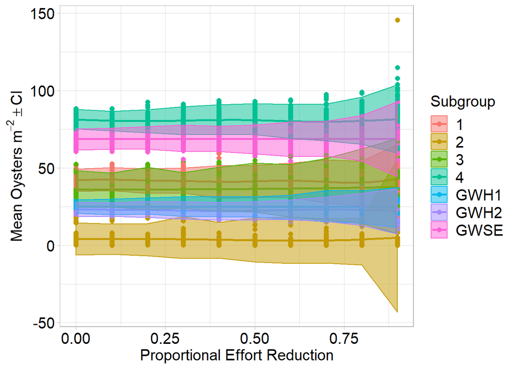

Population Stats based on all data

| Subgroup | pMEAN | pSD | pVAR | nOBS | lower.ci.mean | upper.ci.mean |
| --- | --- | --- | --- | --- | --- | --- |
| 1 | 41.6667 | 71.462 | 5106.78 | 183 | 31.24402 | 52.0893 |
| 2 | 3.8075 | 22.815 | 520.51 | 187 | 0.51623 | 7.0987 |
| 3 | 36.3428 | 64.573 | 4169.71 | 283 | 28.78716 | 43.8984 |
| 4 | 80.5434 | 88.630 | 7855.22 | 633 | 73.62583 | 87.4611 |
| GWH1 | 25.1055 | 33.692 | 1135.15 | 256 | 20.95867 | 29.2523 |
| GWH2 | 23.0237 | 30.541 | 932.74 | 211 | 18.87908 | 27.1683 |
| GWSE | 68.5934 | 74.904 | 5610.58 | 273 | 59.66857 | 77.5182 |

Based on the information above, it appears that the total effort in the Great_Wicomico could be reduced by 40% and still obtain similar population parameters. Each year, total effort (i.e., number of grabs) in each cluster would be as follows:

| Management Subgroup | Future Effort | Current Effort |
| --- | --- | --- |
| 1 | 17 | 14 |
| 2 | 1 | 14 |
| 3 | 6 | 22 |
| 4 | 29 | 49 |
| GWH1 | 9 | 20 |
| GWH2 | 8 | 16 |
| GWSE | 22 | 21 |

This would mean a total of 92 grabs in the Great Wicomico compared to 156 in previous years.

# Chesapeake Bay

All reefs in the Chesapeake Bay region fall within predefined management subgroups.

## Set up strata and summarize

Chesapeake Reef and Management Subgroup

| Station_ID | Site | Management Subgroups |
| --- | --- | --- |
| 357 | Deep Rock | CB1 |
| 367 | Beverly’s 1 | CB1 |
| 383 | Beverly’s 2 | CB1 |
| 384 | Beverly’s 3 | CB1 |
| 206 | Milford Haven | CB2 |
| 312 | Blackberry Hang | CB3 |

Observed vs. Optimal Effort

| Strata | Observed | Optimal |
| --- | --- | --- |
| CB1 | 533 | 531 |
| CB2 | 56 | 10 |
| CB3 | 84 | 132 |
| Total | 673 | 673 |

## Estimate the population mean and variance given the new strata and allocation

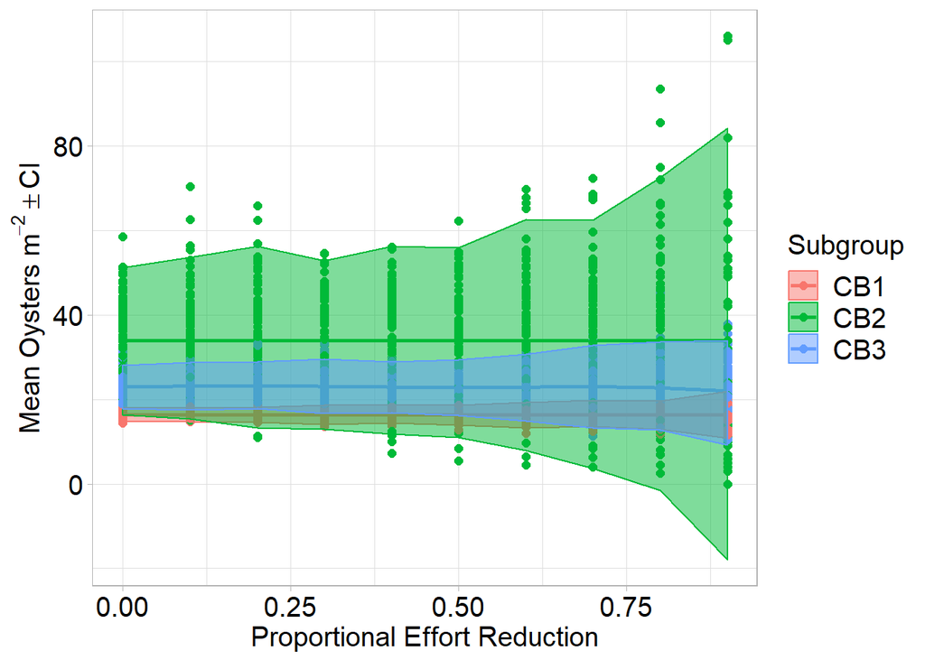

Population Stats based on all data

| Subgroup | pMEAN | pSD | pVAR | nOBS | lower.ci.mean | upper.ci.mean |
| --- | --- | --- | --- | --- | --- | --- |
| CB1 | 16.426 | 20.164 | 406.59 | 533 | 14.710 | 18.142 |
| CB2 | 33.625 | 27.325 | 746.64 | 56 | 26.310 | 40.940 |
| CB3 | 23.119 | 29.016 | 841.94 | 84 | 16.823 | 29.415 |

Based on the information above, it appears that the total effort in the Chesapeake could be reduced by 40% and still obtain similar population parameters. Each year, total effort (i.e., number of grabs) in each cluster would be as follows:

| Subgroup | Future Effort | Current Effort |
| --- | --- | --- |
| CB1 | 25 | 41 |
| CB2 | 3 | 4 |
| CB3 | 6 | 6 |

This would mean a total of 34 grabs in the Chesapeake compared to 52 in previous years.

# Tangier and Pocomoke Sounds

Tangier and Pocomoke reefs are also entirely within management subgroups.

## Set up strata and summarize

Tangier Reef and Management Subgroup

| Station_ID | Site | Management Subgroups |
| --- | --- | --- |
| 1211 | Onancock (18.1) | TP1 |
| 1213 | Parker’s Rock | TP1 |
| 214 | Byrd Rock | TP1 |
| 213 | Marshalls Rock | TP1 |
| 1129 | Hurley’s | TP1 |
| 1110 | #5 H-1 Fox Island | TP1 |
| 1222 | Public Ground #10 H-1 | TP10 |
| 1223 | Public Ground #10 H-2 | TP10 |
| 1207 | PG13 H-1 | TP2 |
| 1208 | PG13 H-2 | TP2 |
| 1209 | PG13 H-3 | TP2 |
| 1210 | PG13 H-4 | TP2 |
| 1214 | PG13 H-5 | TP2 |
| 1124 | #8 H-1 California | TP2 |
| 1125 | #8 H-2 California | TP2 |
| 1126 | #8 H-3 California | TP2 |
| 1127 | #8 H-4 California | TP2 |
| 1111 | #7 H-1 Thoroughfare | TP2 |
| 1114 | #7 H-2 Thoroughfare | TP2 |
| 1115 | #7 H-3 Thoroughfare | TP2 |
| 1112 | #7 H-4 Thoroughfare | TP2 |
| 1113 | #7 H-5 Thoroughfare | TP2 |
| 1220 | Public Ground #9 H-1 | TP9 |
| 1221 | Public Ground #9 H-2 | TP9 |
| 1130 | Cod Harbour | TPS |

Observed vs. Optimal Effort

| Strata | Observed | Optimal |
| --- | --- | --- |
| TP1 | 489 | 459 |
| TP10 | 104 | 99 |
| TP2 | 1436 | 1554 |
| TP9 | 118 | 65 |
| TPS | 44 | 14 |
| Total | 2191 | 2191 |

## Estimate the population mean and variance given the new strata and allocation

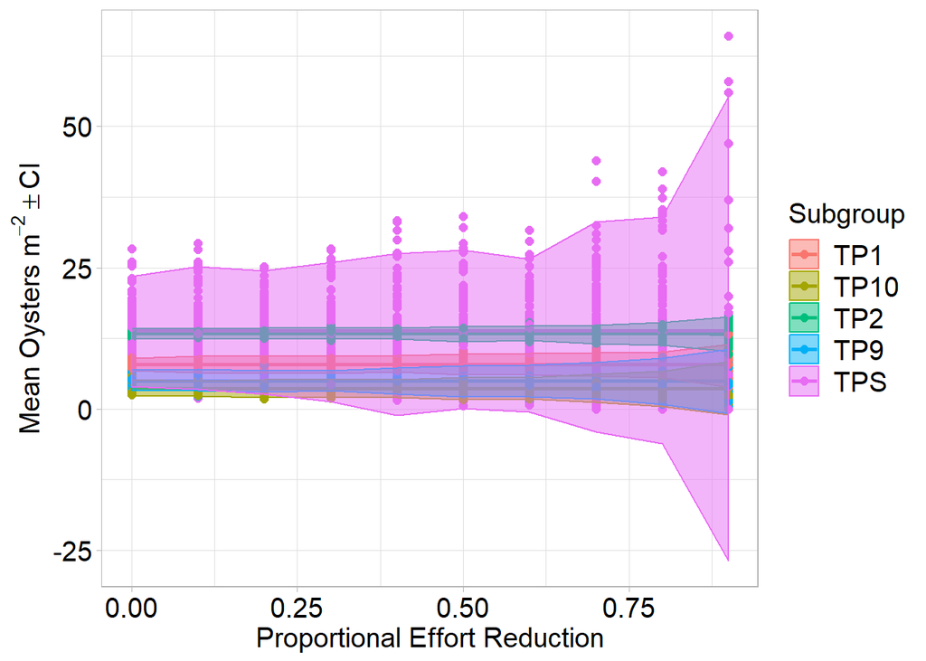

Population Stats based on all data

| Subgroup | pMEAN | pSD | pVAR | nOBS | lower.ci.mean | upper.ci.mean |
| --- | --- | --- | --- | --- | --- | --- |
| TP1 | 7.8896 | 12.9964 | 168.906 | 489 | 6.7348 | 9.0443 |
| TP10 | 3.6731 | 6.5751 | 43.232 | 104 | 2.3945 | 4.9516 |
| TP2 | 13.3524 | 17.2694 | 298.231 | 1436 | 12.4584 | 14.2463 |
| TP9 | 4.9746 | 7.2448 | 52.487 | 118 | 3.6539 | 6.2953 |
| TPS | 13.7273 | 18.5765 | 345.087 | 44 | 8.0832 | 19.3713 |

Based on the information above, it appears that the total effort in Tangier/Pocomoke Sound could be reduced by 40%, except within the sanctuary and still obtain similar population parameters. Each year, total effort (i.e., number of grabs) in each cluster would be as follows:

| Subgroup | Future Effort | Current Effort |
| --- | --- | --- |
| TP1 | 21 | 38 |
| TP10 | 5 | 8 |
| TP2 | 72 | 110 |
| TP9 | 3 | 9 |
| TPS | 7 | 3 |

This would mean a total of 108 grabs in the Tangier compared to 168 in previous years.

# Total Effort

If we allocate effort the way that I’ve shown and described above, here is what it would look like overall:

[output not shown]